# Risk Factor Analysis

## Outcome Variable

**Outcome Variable:** whz

## Predictor Variables

**Intervention Variable:** predfeed3

**Adjustment Set:**

unadjusted

## Stratifying Variables

The analysis was stratified on these variable(s):

- agecat
- studyid
- country

## Data Summary

| agecat | studyid | country | predfeed3 | n_cell | n |
| --- | --- | --- | --- | --- | --- |
| Birth | ki0047075b-MAL-ED | BANGLADESH | 1 | 164 | 202 |
| Birth | ki0047075b-MAL-ED | BANGLADESH | 0 | 38 | 202 |
| Birth | ki0047075b-MAL-ED | BRAZIL | 1 | 23 | 55 |
| Birth | ki0047075b-MAL-ED | BRAZIL | 0 | 32 | 55 |
| Birth | ki0047075b-MAL-ED | INDIA | 1 | 27 | 39 |
| Birth | ki0047075b-MAL-ED | INDIA | 0 | 12 | 39 |
| Birth | ki0047075b-MAL-ED | NEPAL | 1 | 14 | 25 |
| Birth | ki0047075b-MAL-ED | NEPAL | 0 | 11 | 25 |
| Birth | ki0047075b-MAL-ED | PERU | 1 | 145 | 218 |
| Birth | ki0047075b-MAL-ED | PERU | 0 | 73 | 218 |
| Birth | ki0047075b-MAL-ED | SOUTH AFRICA | 1 | 33 | 99 |
| Birth | ki0047075b-MAL-ED | SOUTH AFRICA | 0 | 66 | 99 |
| Birth | ki0047075b-MAL-ED | TANZANIA, UNITED REPUBLIC OF | 1 | 24 | 95 |
| Birth | ki0047075b-MAL-ED | TANZANIA, UNITED REPUBLIC OF | 0 | 71 | 95 |
| Birth | ki1000109-EE | PAKISTAN | 1 | 22 | 22 |
| Birth | ki1000109-EE | PAKISTAN | 0 | 0 | 22 |
| Birth | ki1113344-GMS-Nepal | NEPAL | 1 | 352 | 422 |
| Birth | ki1113344-GMS-Nepal | NEPAL | 0 | 70 | 422 |
| Birth | kiGH5241-JiVitA-3 | BANGLADESH | 1 | 9638 | 10634 |
| Birth | kiGH5241-JiVitA-3 | BANGLADESH | 0 | 996 | 10634 |
| Birth | kiGH5241-JiVitA-4 | BANGLADESH | 1 | 89 | 97 |
| Birth | kiGH5241-JiVitA-4 | BANGLADESH | 0 | 8 | 97 |
| 6 months | ki0047075b-MAL-ED | BANGLADESH | 1 | 191 | 233 |
| 6 months | ki0047075b-MAL-ED | BANGLADESH | 0 | 42 | 233 |
| 6 months | ki0047075b-MAL-ED | BRAZIL | 1 | 93 | 187 |
| 6 months | ki0047075b-MAL-ED | BRAZIL | 0 | 94 | 187 |
| 6 months | ki0047075b-MAL-ED | INDIA | 1 | 147 | 210 |
| 6 months | ki0047075b-MAL-ED | INDIA | 0 | 63 | 210 |
| 6 months | ki0047075b-MAL-ED | NEPAL | 1 | 113 | 227 |
| 6 months | ki0047075b-MAL-ED | NEPAL | 0 | 114 | 227 |
| 6 months | ki0047075b-MAL-ED | PERU | 1 | 176 | 270 |
| 6 months | ki0047075b-MAL-ED | PERU | 0 | 94 | 270 |
| 6 months | ki0047075b-MAL-ED | SOUTH AFRICA | 1 | 63 | 244 |
| 6 months | ki0047075b-MAL-ED | SOUTH AFRICA | 0 | 181 | 244 |
| 6 months | ki0047075b-MAL-ED | TANZANIA, UNITED REPUBLIC OF | 1 | 64 | 212 |
| 6 months | ki0047075b-MAL-ED | TANZANIA, UNITED REPUBLIC OF | 0 | 148 | 212 |
| 6 months | ki1000109-EE | PAKISTAN | 1 | 39 | 39 |
| 6 months | ki1000109-EE | PAKISTAN | 0 | 0 | 39 |
| 6 months | ki1113344-GMS-Nepal | NEPAL | 1 | 367 | 441 |
| 6 months | ki1113344-GMS-Nepal | NEPAL | 0 | 74 | 441 |
| 6 months | kiGH5241-JiVitA-3 | BANGLADESH | 1 | 8500 | 9310 |
| 6 months | kiGH5241-JiVitA-3 | BANGLADESH | 0 | 810 | 9310 |
| 6 months | kiGH5241-JiVitA-4 | BANGLADESH | 1 | 76 | 88 |
| 6 months | kiGH5241-JiVitA-4 | BANGLADESH | 0 | 12 | 88 |
| 24 months | ki0047075b-MAL-ED | BANGLADESH | 1 | 168 | 205 |
| 24 months | ki0047075b-MAL-ED | BANGLADESH | 0 | 37 | 205 |
| 24 months | ki0047075b-MAL-ED | BRAZIL | 1 | 79 | 152 |
| 24 months | ki0047075b-MAL-ED | BRAZIL | 0 | 73 | 152 |
| 24 months | ki0047075b-MAL-ED | INDIA | 1 | 139 | 202 |
| 24 months | ki0047075b-MAL-ED | INDIA | 0 | 63 | 202 |
| 24 months | ki0047075b-MAL-ED | NEPAL | 1 | 110 | 220 |
| 24 months | ki0047075b-MAL-ED | NEPAL | 0 | 110 | 220 |
| 24 months | ki0047075b-MAL-ED | PERU | 1 | 131 | 198 |
| 24 months | ki0047075b-MAL-ED | PERU | 0 | 67 | 198 |
| 24 months | ki0047075b-MAL-ED | SOUTH AFRICA | 1 | 60 | 228 |
| 24 months | ki0047075b-MAL-ED | SOUTH AFRICA | 0 | 168 | 228 |
| 24 months | ki0047075b-MAL-ED | TANZANIA, UNITED REPUBLIC OF | 1 | 54 | 184 |
| 24 months | ki0047075b-MAL-ED | TANZANIA, UNITED REPUBLIC OF | 0 | 130 | 184 |
| 24 months | ki1000109-EE | PAKISTAN | 1 | 20 | 20 |
| 24 months | ki1000109-EE | PAKISTAN | 0 | 0 | 20 |
| 24 months | ki1113344-GMS-Nepal | NEPAL | 1 | 322 | 384 |
| 24 months | ki1113344-GMS-Nepal | NEPAL | 0 | 62 | 384 |
| 24 months | kiGH5241-JiVitA-3 | BANGLADESH | 1 | 4417 | 4833 |
| 24 months | kiGH5241-JiVitA-3 | BANGLADESH | 0 | 416 | 4833 |
| 24 months | kiGH5241-JiVitA-4 | BANGLADESH | 1 | 135 | 150 |
| 24 months | kiGH5241-JiVitA-4 | BANGLADESH | 0 | 15 | 150 |

The following strata were considered:

- agecat: 24 months, studyid: ki0047075b-MAL-ED, country: BANGLADESH
- agecat: 24 months, studyid: ki0047075b-MAL-ED, country: BRAZIL
- agecat: 24 months, studyid: ki0047075b-MAL-ED, country: INDIA
- agecat: 24 months, studyid: ki0047075b-MAL-ED, country: NEPAL
- agecat: 24 months, studyid: ki0047075b-MAL-ED, country: PERU
- agecat: 24 months, studyid: ki0047075b-MAL-ED, country: SOUTH AFRICA
- agecat: 24 months, studyid: ki0047075b-MAL-ED, country: TANZANIA, UNITED REPUBLIC OF
- agecat: 24 months, studyid: ki1000109-EE, country: PAKISTAN
- agecat: 24 months, studyid: ki1113344-GMS-Nepal, country: NEPAL
- agecat: 24 months, studyid: kiGH5241-JiVitA-3, country: BANGLADESH
- agecat: 24 months, studyid: kiGH5241-JiVitA-4, country: BANGLADESH
- agecat: 6 months, studyid: ki0047075b-MAL-ED, country: BANGLADESH
- agecat: 6 months, studyid: ki0047075b-MAL-ED, country: BRAZIL
- agecat: 6 months, studyid: ki0047075b-MAL-ED, country: INDIA
- agecat: 6 months, studyid: ki0047075b-MAL-ED, country: NEPAL
- agecat: 6 months, studyid: ki0047075b-MAL-ED, country: PERU
- agecat: 6 months, studyid: ki0047075b-MAL-ED, country: SOUTH AFRICA
- agecat: 6 months, studyid: ki0047075b-MAL-ED, country: TANZANIA, UNITED REPUBLIC OF
- agecat: 6 months, studyid: ki1000109-EE, country: PAKISTAN
- agecat: 6 months, studyid: ki1113344-GMS-Nepal, country: NEPAL
- agecat: 6 months, studyid: kiGH5241-JiVitA-3, country: BANGLADESH
- agecat: 6 months, studyid: kiGH5241-JiVitA-4, country: BANGLADESH
- agecat: Birth, studyid: ki0047075b-MAL-ED, country: BANGLADESH
- agecat: Birth, studyid: ki0047075b-MAL-ED, country: BRAZIL
- agecat: Birth, studyid: ki0047075b-MAL-ED, country: INDIA
- agecat: Birth, studyid: ki0047075b-MAL-ED, country: NEPAL
- agecat: Birth, studyid: ki0047075b-MAL-ED, country: PERU
- agecat: Birth, studyid: ki0047075b-MAL-ED, country: SOUTH AFRICA
- agecat: Birth, studyid: ki0047075b-MAL-ED, country: TANZANIA, UNITED REPUBLIC OF
- agecat: Birth, studyid: ki1000109-EE, country: PAKISTAN
- agecat: Birth, studyid: ki1113344-GMS-Nepal, country: NEPAL
- agecat: Birth, studyid: kiGH5241-JiVitA-3, country: BANGLADESH
- agecat: Birth, studyid: kiGH5241-JiVitA-4, country: BANGLADESH

### Dropped Strata

Some strata were dropped due to rare outcomes:

- agecat: Birth, studyid: ki1000109-EE, country: PAKISTAN
- agecat: 6 months, studyid: ki1000109-EE, country: PAKISTAN
- agecat: 24 months, studyid: ki1000109-EE, country: PAKISTAN

## Methods Detail

We’re interested in the causal parameters $E[Y_a]$ for all values of $a \in \mathcal{A}$. These parameters represent the mean outcome if, possibly contrary to fact, we intervened to set all units to have $A=a$. Under the randomization and positivity assumptions, these are identified by the statistical parameters $\psi_a=E_W[E_{Y|A,W}(Y|A=a,W)]$. In addition, we’re interested in the mean of $Y$, $E[Y]$ under no intervention (the observed mean). We will estimate these parameters by using SuperLearner to fit the relevant likelihood factors – $E_{Y|A,W}(Y|A=a,W)$ and $p(A=a|W)$, and then updating our likelihood fit using a joint TMLE.

For unadjusted analyses ($W=\{\}$), initial likelihoods were estimated using Lrnr_glm to estimate the simple $E(Y|A)$ and Lrnr_mean to estimate $p(A)$. For adjusted analyses, a small library containing Lrnr_glmnet, Lrnr_xgboost, and Lrnr_mean was used.

Having estimated these parameters, we will then use the delta method to estimate relative risks and attributable risks relative to a prespecified baseline level of $A$.

# Results Detail

## Results Plots

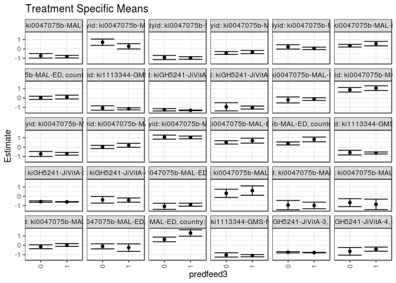

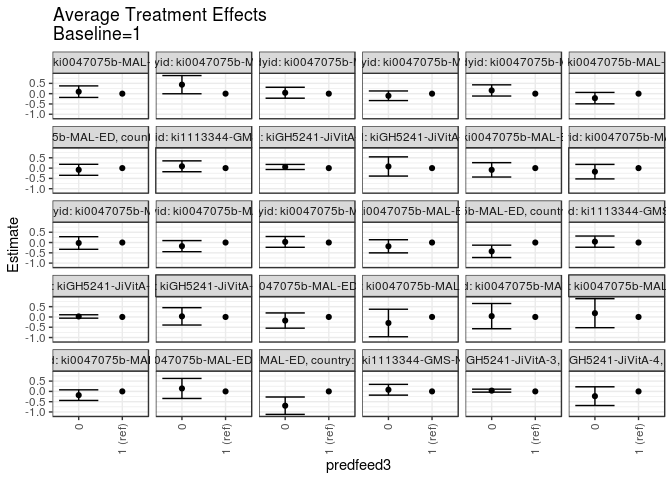

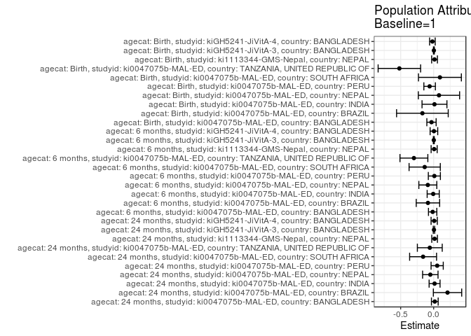

## Results Table

### Parameter: TSM

| agecat | studyid | country | intervention_level | baseline_level | estimate | ci_lower | ci_upper |
| --- | --- | --- | --- | --- | --- | --- | --- |
| Birth | ki0047075b-MAL-ED | BANGLADESH | 1 | NA | -0.9082927 | -1.0737392 | -0.7428462 |
| Birth | ki0047075b-MAL-ED | BANGLADESH | 0 | NA | -1.0828947 | -1.4144597 | -0.7513298 |
| Birth | ki0047075b-MAL-ED | BRAZIL | 1 | NA | 0.6021739 | 0.1009158 | 1.1034320 |
| Birth | ki0047075b-MAL-ED | BRAZIL | 0 | NA | 0.3090625 | -0.1344152 | 0.7525402 |
| Birth | ki0047075b-MAL-ED | INDIA | 1 | NA | -0.9903704 | -1.3424774 | -0.6382633 |
| Birth | ki0047075b-MAL-ED | INDIA | 0 | NA | -0.9500000 | -1.4513194 | -0.4486806 |
| Birth | ki0047075b-MAL-ED | NEPAL | 1 | NA | -0.8750000 | -1.4361870 | -0.3138130 |
| Birth | ki0047075b-MAL-ED | NEPAL | 0 | NA | -0.6918182 | -1.1195999 | -0.2640364 |
| Birth | ki0047075b-MAL-ED | PERU | 1 | NA | 0.0275862 | -0.1229573 | 0.1781297 |
| Birth | ki0047075b-MAL-ED | PERU | 0 | NA | -0.1549315 | -0.3652693 | 0.0554063 |
| Birth | ki0047075b-MAL-ED | SOUTH AFRICA | 1 | NA | -0.2539394 | -0.6587302 | 0.1508515 |
| Birth | ki0047075b-MAL-ED | SOUTH AFRICA | 0 | NA | -0.1113636 | -0.3819053 | 0.1591780 |
| Birth | ki0047075b-MAL-ED | TANZANIA, UNITED REPUBLIC OF | 1 | NA | 1.3191667 | 0.9752127 | 1.6631206 |
| Birth | ki0047075b-MAL-ED | TANZANIA, UNITED REPUBLIC OF | 0 | NA | 0.6240845 | 0.3782662 | 0.8699029 |
| Birth | ki1113344-GMS-Nepal | NEPAL | 1 | NA | -1.1124432 | -1.2336464 | -0.9912399 |
| Birth | ki1113344-GMS-Nepal | NEPAL | 0 | NA | -1.0324286 | -1.2641944 | -0.8006628 |
| Birth | kiGH5241-JiVitA-3 | BANGLADESH | 1 | NA | -0.7832777 | -0.8066004 | -0.7599549 |
| Birth | kiGH5241-JiVitA-3 | BANGLADESH | 0 | NA | -0.7468273 | -0.8164023 | -0.6772523 |
| Birth | kiGH5241-JiVitA-4 | BANGLADESH | 1 | NA | -0.4156180 | -0.6383645 | -0.1928714 |
| Birth | kiGH5241-JiVitA-4 | BANGLADESH | 0 | NA | -0.6475000 | -1.0569566 | -0.2380434 |
| 6 months | ki0047075b-MAL-ED | BANGLADESH | 1 | NA | -0.1151571 | -0.2601757 | 0.0298616 |
| 6 months | ki0047075b-MAL-ED | BANGLADESH | 0 | NA | -0.2002381 | -0.5182998 | 0.1178236 |
| 6 months | ki0047075b-MAL-ED | BRAZIL | 1 | NA | 1.0621147 | 0.8082040 | 1.3160254 |
| 6 months | ki0047075b-MAL-ED | BRAZIL | 0 | NA | 0.8896365 | 0.6459925 | 1.1332806 |
| 6 months | ki0047075b-MAL-ED | INDIA | 1 | NA | -0.7117971 | -0.8588634 | -0.5647307 |
| 6 months | ki0047075b-MAL-ED | INDIA | 0 | NA | -0.7344709 | -1.0020269 | -0.4669149 |
| 6 months | ki0047075b-MAL-ED | NEPAL | 1 | NA | 0.1925959 | -0.0134763 | 0.3986680 |
| 6 months | ki0047075b-MAL-ED | NEPAL | 0 | NA | 0.0164766 | -0.1576474 | 0.1906006 |
| 6 months | ki0047075b-MAL-ED | PERU | 1 | NA | 1.0407955 | 0.8927433 | 1.1888476 |
| 6 months | ki0047075b-MAL-ED | PERU | 0 | NA | 1.0712943 | 0.8546571 | 1.2879315 |
| 6 months | ki0047075b-MAL-ED | SOUTH AFRICA | 1 | NA | 0.6922487 | 0.4301816 | 0.9543158 |
| 6 months | ki0047075b-MAL-ED | SOUTH AFRICA | 0 | NA | 0.5091252 | 0.3278304 | 0.6904200 |
| 6 months | ki0047075b-MAL-ED | TANZANIA, UNITED REPUBLIC OF | 1 | NA | 0.8250000 | 0.5720648 | 1.0779352 |
| 6 months | ki0047075b-MAL-ED | TANZANIA, UNITED REPUBLIC OF | 0 | NA | 0.3963626 | 0.2350832 | 0.5576420 |
| 6 months | ki1113344-GMS-Nepal | NEPAL | 1 | NA | -0.6271798 | -0.7373913 | -0.5169683 |
| 6 months | ki1113344-GMS-Nepal | NEPAL | 0 | NA | -0.5836712 | -0.8323071 | -0.3350353 |
| 6 months | kiGH5241-JiVitA-3 | BANGLADESH | 1 | NA | -0.6062741 | -0.6319474 | -0.5806008 |
| 6 months | kiGH5241-JiVitA-3 | BANGLADESH | 0 | NA | -0.5812593 | -0.6603089 | -0.5022097 |
| 6 months | kiGH5241-JiVitA-4 | BANGLADESH | 1 | NA | -0.4150000 | -0.6422302 | -0.1877698 |
| 6 months | kiGH5241-JiVitA-4 | BANGLADESH | 0 | NA | -0.3858333 | -0.7373291 | -0.0343375 |
| 24 months | ki0047075b-MAL-ED | BANGLADESH | 1 | NA | -0.8251190 | -0.9637372 | -0.6865009 |
| 24 months | ki0047075b-MAL-ED | BANGLADESH | 0 | NA | -0.7285135 | -0.9723621 | -0.4846650 |
| 24 months | ki0047075b-MAL-ED | BRAZIL | 1 | NA | 0.2879958 | 0.0035497 | 0.5724418 |
| 24 months | ki0047075b-MAL-ED | BRAZIL | 0 | NA | 0.7255023 | 0.3881821 | 1.0628225 |
| 24 months | ki0047075b-MAL-ED | INDIA | 1 | NA | -0.9657914 | -1.1045284 | -0.8270543 |
| 24 months | ki0047075b-MAL-ED | INDIA | 0 | NA | -0.9205556 | -1.1466042 | -0.6945069 |
| 24 months | ki0047075b-MAL-ED | NEPAL | 1 | NA | -0.3284091 | -0.5014233 | -0.1553949 |
| 24 months | ki0047075b-MAL-ED | NEPAL | 0 | NA | -0.4296818 | -0.5861835 | -0.2731801 |
| 24 months | ki0047075b-MAL-ED | PERU | 1 | NA | 0.0643957 | -0.0680445 | 0.1968358 |
| 24 months | ki0047075b-MAL-ED | PERU | 0 | NA | 0.2216418 | -0.0148699 | 0.4581535 |
| 24 months | ki0047075b-MAL-ED | SOUTH AFRICA | 1 | NA | 0.5721111 | 0.3346855 | 0.8095367 |
| 24 months | ki0047075b-MAL-ED | SOUTH AFRICA | 0 | NA | 0.3549256 | 0.2137440 | 0.4961072 |
| 24 months | ki0047075b-MAL-ED | TANZANIA, UNITED REPUBLIC OF | 1 | NA | 0.1080556 | -0.0957780 | 0.3118891 |
| 24 months | ki0047075b-MAL-ED | TANZANIA, UNITED REPUBLIC OF | 0 | NA | 0.0252821 | -0.1463550 | 0.1969191 |
| 24 months | ki1113344-GMS-Nepal | NEPAL | 1 | NA | -1.1537474 | -1.2663233 | -1.0411715 |
| 24 months | ki1113344-GMS-Nepal | NEPAL | 0 | NA | -1.0663978 | -1.3047957 | -0.8280000 |
| 24 months | kiGH5241-JiVitA-3 | BANGLADESH | 1 | NA | -1.3156600 | -1.3475591 | -1.2837608 |
| 24 months | kiGH5241-JiVitA-3 | BANGLADESH | 0 | NA | -1.2609615 | -1.3812131 | -1.1407099 |
| 24 months | kiGH5241-JiVitA-4 | BANGLADESH | 1 | NA | -1.0175556 | -1.1803689 | -0.8547422 |
| 24 months | kiGH5241-JiVitA-4 | BANGLADESH | 0 | NA | -0.9380000 | -1.3723208 | -0.5036792 |

### Parameter: E(Y)

| agecat | studyid | country | intervention_level | baseline_level | estimate | ci_lower | ci_upper |
| --- | --- | --- | --- | --- | --- | --- | --- |
| Birth | ki0047075b-MAL-ED | BANGLADESH | NA | NA | -0.9411386 | -1.0895370 | -0.7927402 |
| Birth | ki0047075b-MAL-ED | BRAZIL | NA | NA | 0.4316364 | 0.0969688 | 0.7663039 |
| Birth | ki0047075b-MAL-ED | INDIA | NA | NA | -0.9779487 | -1.2664810 | -0.6894164 |
| Birth | ki0047075b-MAL-ED | NEPAL | NA | NA | -0.7944000 | -1.1625222 | -0.4262778 |
| Birth | ki0047075b-MAL-ED | PERU | NA | NA | -0.0335321 | -0.1564905 | 0.0894263 |
| Birth | ki0047075b-MAL-ED | SOUTH AFRICA | NA | NA | -0.1588889 | -0.3845288 | 0.0667510 |
| Birth | ki0047075b-MAL-ED | TANZANIA, UNITED REPUBLIC OF | NA | NA | 0.7996842 | 0.5874808 | 1.0118876 |
| Birth | ki1113344-GMS-Nepal | NEPAL | NA | NA | -1.0991706 | -1.2073693 | -0.9909719 |
| Birth | kiGH5241-JiVitA-3 | BANGLADESH | NA | NA | -0.7798636 | -0.8022140 | -0.7575133 |
| Birth | kiGH5241-JiVitA-4 | BANGLADESH | NA | NA | -0.4347423 | -0.6441144 | -0.2253701 |
| 6 months | ki0047075b-MAL-ED | BANGLADESH | NA | NA | -0.1304936 | -0.2625419 | 0.0015547 |
| 6 months | ki0047075b-MAL-ED | BRAZIL | NA | NA | 0.9754144 | 0.7990651 | 1.1517638 |
| 6 months | ki0047075b-MAL-ED | INDIA | NA | NA | -0.7185992 | -0.8491469 | -0.5880515 |
| 6 months | ki0047075b-MAL-ED | NEPAL | NA | NA | 0.1041483 | -0.0311352 | 0.2394318 |
| 6 months | ki0047075b-MAL-ED | PERU | NA | NA | 1.0514136 | 0.9289176 | 1.1739096 |
| 6 months | ki0047075b-MAL-ED | SOUTH AFRICA | NA | NA | 0.5564071 | 0.4055220 | 0.7072922 |
| 6 months | ki0047075b-MAL-ED | TANZANIA, UNITED REPUBLIC OF | NA | NA | 0.5257626 | 0.3871543 | 0.6643709 |
| 6 months | ki1113344-GMS-Nepal | NEPAL | NA | NA | -0.6198791 | -0.7206518 | -0.5191063 |
| 6 months | kiGH5241-JiVitA-3 | BANGLADESH | NA | NA | -0.6040977 | -0.6286619 | -0.5795335 |
| 6 months | kiGH5241-JiVitA-4 | BANGLADESH | NA | NA | -0.4110227 | -0.6122701 | -0.2097753 |
| 24 months | ki0047075b-MAL-ED | BANGLADESH | NA | NA | -0.8076829 | -0.9296166 | -0.6857493 |
| 24 months | ki0047075b-MAL-ED | BRAZIL | NA | NA | 0.4981140 | 0.2760418 | 0.7201863 |
| 24 months | ki0047075b-MAL-ED | INDIA | NA | NA | -0.9516832 | -1.0703961 | -0.8329703 |
| 24 months | ki0047075b-MAL-ED | NEPAL | NA | NA | -0.3790455 | -0.4958857 | -0.2622052 |
| 24 months | ki0047075b-MAL-ED | PERU | NA | NA | 0.1176052 | -0.0015211 | 0.2367315 |
| 24 months | ki0047075b-MAL-ED | SOUTH AFRICA | NA | NA | 0.4120797 | 0.2900939 | 0.5340654 |
| 24 months | ki0047075b-MAL-ED | TANZANIA, UNITED REPUBLIC OF | NA | NA | 0.0495743 | -0.0857535 | 0.1849021 |
| 24 months | ki1113344-GMS-Nepal | NEPAL | NA | NA | -1.1396441 | -1.2416403 | -1.0376479 |
| 24 months | kiGH5241-JiVitA-3 | BANGLADESH | NA | NA | -1.3109518 | -1.3423299 | -1.2795737 |
| 24 months | kiGH5241-JiVitA-4 | BANGLADESH | NA | NA | -1.0096000 | -1.1619164 | -0.8572836 |

### Parameter: ATE

| agecat | studyid | country | intervention_level | baseline_level | estimate | ci_lower | ci_upper |
| --- | --- | --- | --- | --- | --- | --- | --- |
| Birth | ki0047075b-MAL-ED | BANGLADESH | 1 | 1 | 0.0000000 | 0.0000000 | 0.0000000 |
| Birth | ki0047075b-MAL-ED | BANGLADESH | 0 | 1 | -0.1746021 | -0.5451528 | 0.1959487 |
| Birth | ki0047075b-MAL-ED | BRAZIL | 1 | 1 | 0.0000000 | 0.0000000 | 0.0000000 |
| Birth | ki0047075b-MAL-ED | BRAZIL | 0 | 1 | -0.2931114 | -0.9623887 | 0.3761659 |
| Birth | ki0047075b-MAL-ED | INDIA | 1 | 1 | 0.0000000 | 0.0000000 | 0.0000000 |
| Birth | ki0047075b-MAL-ED | INDIA | 0 | 1 | 0.0403704 | -0.5722474 | 0.6529881 |
| Birth | ki0047075b-MAL-ED | NEPAL | 1 | 1 | 0.0000000 | 0.0000000 | 0.0000000 |
| Birth | ki0047075b-MAL-ED | NEPAL | 0 | 1 | 0.1831818 | -0.5224583 | 0.8888220 |
| Birth | ki0047075b-MAL-ED | PERU | 1 | 1 | 0.0000000 | 0.0000000 | 0.0000000 |
| Birth | ki0047075b-MAL-ED | PERU | 0 | 1 | -0.1825177 | -0.4411784 | 0.0761429 |
| Birth | ki0047075b-MAL-ED | SOUTH AFRICA | 1 | 1 | 0.0000000 | 0.0000000 | 0.0000000 |
| Birth | ki0047075b-MAL-ED | SOUTH AFRICA | 0 | 1 | 0.1425758 | -0.3443004 | 0.6294519 |
| Birth | ki0047075b-MAL-ED | TANZANIA, UNITED REPUBLIC OF | 1 | 1 | 0.0000000 | 0.0000000 | 0.0000000 |
| Birth | ki0047075b-MAL-ED | TANZANIA, UNITED REPUBLIC OF | 0 | 1 | -0.6950822 | -1.1178480 | -0.2723163 |
| Birth | ki1113344-GMS-Nepal | NEPAL | 1 | 1 | 0.0000000 | 0.0000000 | 0.0000000 |
| Birth | ki1113344-GMS-Nepal | NEPAL | 0 | 1 | 0.0800146 | -0.1815301 | 0.3415593 |
| Birth | kiGH5241-JiVitA-3 | BANGLADESH | 1 | 1 | 0.0000000 | 0.0000000 | 0.0000000 |
| Birth | kiGH5241-JiVitA-3 | BANGLADESH | 0 | 1 | 0.0364503 | -0.0360810 | 0.1089817 |
| Birth | kiGH5241-JiVitA-4 | BANGLADESH | 1 | 1 | 0.0000000 | 0.0000000 | 0.0000000 |
| Birth | kiGH5241-JiVitA-4 | BANGLADESH | 0 | 1 | -0.2318820 | -0.6871466 | 0.2233826 |
| 6 months | ki0047075b-MAL-ED | BANGLADESH | 1 | 1 | 0.0000000 | 0.0000000 | 0.0000000 |
| 6 months | ki0047075b-MAL-ED | BANGLADESH | 0 | 1 | -0.0850810 | -0.4346431 | 0.2644810 |
| 6 months | ki0047075b-MAL-ED | BRAZIL | 1 | 1 | 0.0000000 | 0.0000000 | 0.0000000 |
| 6 months | ki0047075b-MAL-ED | BRAZIL | 0 | 1 | -0.1724782 | -0.5243774 | 0.1794211 |
| 6 months | ki0047075b-MAL-ED | INDIA | 1 | 1 | 0.0000000 | 0.0000000 | 0.0000000 |
| 6 months | ki0047075b-MAL-ED | INDIA | 0 | 1 | -0.0226738 | -0.3279847 | 0.2826370 |
| 6 months | ki0047075b-MAL-ED | NEPAL | 1 | 1 | 0.0000000 | 0.0000000 | 0.0000000 |
| 6 months | ki0047075b-MAL-ED | NEPAL | 0 | 1 | -0.1761193 | -0.4459060 | 0.0936675 |
| 6 months | ki0047075b-MAL-ED | PERU | 1 | 1 | 0.0000000 | 0.0000000 | 0.0000000 |
| 6 months | ki0047075b-MAL-ED | PERU | 0 | 1 | 0.0304989 | -0.2318961 | 0.2928938 |
| 6 months | ki0047075b-MAL-ED | SOUTH AFRICA | 1 | 1 | 0.0000000 | 0.0000000 | 0.0000000 |
| 6 months | ki0047075b-MAL-ED | SOUTH AFRICA | 0 | 1 | -0.1831234 | -0.5017878 | 0.1355409 |
| 6 months | ki0047075b-MAL-ED | TANZANIA, UNITED REPUBLIC OF | 1 | 1 | 0.0000000 | 0.0000000 | 0.0000000 |
| 6 months | ki0047075b-MAL-ED | TANZANIA, UNITED REPUBLIC OF | 0 | 1 | -0.4286374 | -0.7286161 | -0.1286586 |
| 6 months | ki1113344-GMS-Nepal | NEPAL | 1 | 1 | 0.0000000 | 0.0000000 | 0.0000000 |
| 6 months | ki1113344-GMS-Nepal | NEPAL | 0 | 1 | 0.0435087 | -0.2284590 | 0.3154763 |
| 6 months | kiGH5241-JiVitA-3 | BANGLADESH | 1 | 1 | 0.0000000 | 0.0000000 | 0.0000000 |
| 6 months | kiGH5241-JiVitA-3 | BANGLADESH | 0 | 1 | 0.0250149 | -0.0576286 | 0.1076583 |
| 6 months | kiGH5241-JiVitA-4 | BANGLADESH | 1 | 1 | 0.0000000 | 0.0000000 | 0.0000000 |
| 6 months | kiGH5241-JiVitA-4 | BANGLADESH | 0 | 1 | 0.0291667 | -0.3927898 | 0.4511231 |
| 24 months | ki0047075b-MAL-ED | BANGLADESH | 1 | 1 | 0.0000000 | 0.0000000 | 0.0000000 |
| 24 months | ki0047075b-MAL-ED | BANGLADESH | 0 | 1 | 0.0966055 | -0.1838889 | 0.3770999 |
| 24 months | ki0047075b-MAL-ED | BRAZIL | 1 | 1 | 0.0000000 | 0.0000000 | 0.0000000 |
| 24 months | ki0047075b-MAL-ED | BRAZIL | 0 | 1 | 0.4375065 | -0.0037355 | 0.8787485 |
| 24 months | ki0047075b-MAL-ED | INDIA | 1 | 1 | 0.0000000 | 0.0000000 | 0.0000000 |
| 24 months | ki0047075b-MAL-ED | INDIA | 0 | 1 | 0.0452358 | -0.2199923 | 0.3104640 |
| 24 months | ki0047075b-MAL-ED | NEPAL | 1 | 1 | 0.0000000 | 0.0000000 | 0.0000000 |
| 24 months | ki0047075b-MAL-ED | NEPAL | 0 | 1 | -0.1012727 | -0.3345680 | 0.1320225 |
| 24 months | ki0047075b-MAL-ED | PERU | 1 | 1 | 0.0000000 | 0.0000000 | 0.0000000 |
| 24 months | ki0047075b-MAL-ED | PERU | 0 | 1 | 0.1572461 | -0.1138224 | 0.4283147 |
| 24 months | ki0047075b-MAL-ED | SOUTH AFRICA | 1 | 1 | 0.0000000 | 0.0000000 | 0.0000000 |
| 24 months | ki0047075b-MAL-ED | SOUTH AFRICA | 0 | 1 | -0.2171855 | -0.4934158 | 0.0590448 |
| 24 months | ki0047075b-MAL-ED | TANZANIA, UNITED REPUBLIC OF | 1 | 1 | 0.0000000 | 0.0000000 | 0.0000000 |
| 24 months | ki0047075b-MAL-ED | TANZANIA, UNITED REPUBLIC OF | 0 | 1 | -0.0827735 | -0.3492457 | 0.1836986 |
| 24 months | ki1113344-GMS-Nepal | NEPAL | 1 | 1 | 0.0000000 | 0.0000000 | 0.0000000 |
| 24 months | ki1113344-GMS-Nepal | NEPAL | 0 | 1 | 0.0873496 | -0.1762920 | 0.3509911 |
| 24 months | kiGH5241-JiVitA-3 | BANGLADESH | 1 | 1 | 0.0000000 | 0.0000000 | 0.0000000 |
| 24 months | kiGH5241-JiVitA-3 | BANGLADESH | 0 | 1 | 0.0546984 | -0.0681994 | 0.1775962 |
| 24 months | kiGH5241-JiVitA-4 | BANGLADESH | 1 | 1 | 0.0000000 | 0.0000000 | 0.0000000 |
| 24 months | kiGH5241-JiVitA-4 | BANGLADESH | 0 | 1 | 0.0795556 | -0.3867351 | 0.5458462 |

### Parameter: PAR

| agecat | studyid | country | intervention_level | baseline_level | estimate | ci_lower | ci_upper |
| --- | --- | --- | --- | --- | --- | --- | --- |
| Birth | ki0047075b-MAL-ED | BANGLADESH | 1 | NA | -0.0328459 | -0.1031889 | 0.0374970 |
| Birth | ki0047075b-MAL-ED | BRAZIL | 1 | NA | -0.1705375 | -0.5618400 | 0.2207649 |
| Birth | ki0047075b-MAL-ED | INDIA | 1 | NA | 0.0124217 | -0.1761692 | 0.2010125 |
| Birth | ki0047075b-MAL-ED | NEPAL | 1 | NA | 0.0806000 | -0.2320056 | 0.3932056 |
| Birth | ki0047075b-MAL-ED | PERU | 1 | NA | -0.0611183 | -0.1484890 | 0.0262523 |
| Birth | ki0047075b-MAL-ED | SOUTH AFRICA | 1 | NA | 0.0950505 | -0.2298063 | 0.4199073 |
| Birth | ki0047075b-MAL-ED | TANZANIA, UNITED REPUBLIC OF | 1 | NA | -0.5194825 | -0.8412895 | -0.1976754 |
| Birth | ki1113344-GMS-Nepal | NEPAL | 1 | NA | 0.0132726 | -0.0302047 | 0.0567498 |
| Birth | kiGH5241-JiVitA-3 | BANGLADESH | 1 | NA | 0.0034140 | -0.0034110 | 0.0102390 |
| Birth | kiGH5241-JiVitA-4 | BANGLADESH | 1 | NA | -0.0191243 | -0.0615870 | 0.0233385 |
| 6 months | ki0047075b-MAL-ED | BANGLADESH | 1 | NA | -0.0153365 | -0.0784881 | 0.0478151 |
| 6 months | ki0047075b-MAL-ED | BRAZIL | 1 | NA | -0.0867003 | -0.2640244 | 0.0906239 |
| 6 months | ki0047075b-MAL-ED | INDIA | 1 | NA | -0.0068022 | -0.0984062 | 0.0848019 |
| 6 months | ki0047075b-MAL-ED | NEPAL | 1 | NA | -0.0884476 | -0.2244207 | 0.0475256 |
| 6 months | ki0047075b-MAL-ED | PERU | 1 | NA | 0.0106181 | -0.0807507 | 0.1019869 |
| 6 months | ki0047075b-MAL-ED | SOUTH AFRICA | 1 | NA | -0.1358416 | -0.3724425 | 0.1007594 |
| 6 months | ki0047075b-MAL-ED | TANZANIA, UNITED REPUBLIC OF | 1 | NA | -0.2992374 | -0.5103330 | -0.0881419 |
| 6 months | ki1113344-GMS-Nepal | NEPAL | 1 | NA | 0.0073008 | -0.0383608 | 0.0529623 |
| 6 months | kiGH5241-JiVitA-3 | BANGLADESH | 1 | NA | 0.0021764 | -0.0050005 | 0.0093533 |
| 6 months | kiGH5241-JiVitA-4 | BANGLADESH | 1 | NA | 0.0039773 | -0.0536508 | 0.0616053 |
| 24 months | ki0047075b-MAL-ED | BANGLADESH | 1 | NA | 0.0174361 | -0.0334458 | 0.0683180 |
| 24 months | ki0047075b-MAL-ED | BRAZIL | 1 | NA | 0.2101183 | -0.0046428 | 0.4248793 |
| 24 months | ki0047075b-MAL-ED | INDIA | 1 | NA | 0.0141082 | -0.0686622 | 0.0968786 |
| 24 months | ki0047075b-MAL-ED | NEPAL | 1 | NA | -0.0506364 | -0.1674766 | 0.0662039 |
| 24 months | ki0047075b-MAL-ED | PERU | 1 | NA | 0.0532095 | -0.0391022 | 0.1455213 |
| 24 months | ki0047075b-MAL-ED | SOUTH AFRICA | 1 | NA | -0.1600314 | -0.3639494 | 0.0438865 |
| 24 months | ki0047075b-MAL-ED | TANZANIA, UNITED REPUBLIC OF | 1 | NA | -0.0584813 | -0.2468288 | 0.1298663 |
| 24 months | ki1113344-GMS-Nepal | NEPAL | 1 | NA | 0.0141033 | -0.0285853 | 0.0567920 |
| 24 months | kiGH5241-JiVitA-3 | BANGLADESH | 1 | NA | 0.0047082 | -0.0058343 | 0.0152506 |
| 24 months | kiGH5241-JiVitA-4 | BANGLADESH | 1 | NA | 0.0079556 | -0.0390048 | 0.0549159 |